# Exp4b LDT-LDT

Yingcan Carol Wang

## Introduction

This experiment is part of a series experiments we conducted to investigate how different experimental tasks influence speech perception. Previously, we conducted three online behavioural experiments (Exp1, 3 & 4a) and one MEG experiment (Exp2) manipulating the process of spoken word recognition and learning through the competitor priming effect (Monsell & Hirsh, 1998). The competitor priming effect shows that a spoken word prime (e.g. *captain*) delays subsequent recognition of a neighbouring target spoken word sharing the same initial segments (e.g. *captive*). We replicated this effect in Exp1&2 by presenting interleaved prime and target items in a lexical decision task (LDT). In Exp3, we replaced the LDT with the pause detection task (PDT; Mattys & Clark, 2002; Gaskell & Dumay, 2003) and found surprising results that a pseudoword prime, but not a word prime, delayed word recognition.

In order to examine why these two tasks resulted in different response patterns and tease apart their effects during competitor priming, we then pre-registered and conducted Exp4a (osf.io/9453v), which used PDT in the prime phase and LDT in the target phase separately, and each prime was repeatedly presented for 4 times. However, we only found a marginal trend similar to the results in Exp1-2. Here, in Exp4b, we will again use the LDT in both phases to determine whether the results from Exp4a were due to the change of tasks or the separate prime/target phase design which lengthened the prime-target lag.

```r
##Load packages
library(plyr)
library(dplyr)
library(ggplot2)
library(ggsignif)
library(lattice)
library(labeling)
library(RColorBrewer)
library(lme4)
#library(rlang)
library(lmerTest)
library(emmeans)
#library(scales) # for oob=rescale_none
#library(Rmisc)
library(ordinal)
library(effects)
#library(afex) #remove correlation in lmer
library(brms) # bayesian
library(ggmcmc)
library(ggthemes)
library(ggridges)
library(bayestestR)
library(simr)
library(kableExtra)
```

```r
# load data
df <- read.csv("Exp4b_data.csv", head = TRUE, stringsAsFactors = FALSE)
```

The data were collected using the Prolific Academic online platform (https://www.prolific.co/), where 86 native British English speakers participated in the experiment.

The variables of interest are:

1. **rt**: response times (ms) to the audio stimuli
2. **key_press**: the keys participants pressed to make the response, i.e. P (represented by integer 80), Q (81)
3. **subject**: integer numbers representing each participant
4. **correct**: participants' accuracy, 1 is correct, 0 is incorrect, this will be calculated below
5. **item**: the item heard by participants in each trial
6. **condition**: experimental conditions including:
   - a word prime a word (WW)
   - a pseudoword prime a word (PW)
   - a pseudoword prime a pseudoword (PP)
   - a word prime a pseudoword (WP)
   - unprimed word (W)
   - unprimed pseudoword (P)
   - filler (f)
7. **lexicality**: whether an item is a word or a pseudoword

## Part 1. Prime phase

In the prime phase, participants heard 108 different words (e.g. *hygeiene*) and pseudowords (e.g. *letto*) being repeated 4 times across 4 blocks.These items in prime phase serve as stimuli that will perturb items to be presented in the target phase. We are only interested in descriptive statistical results from the prime phase.

### Data cleaning

The first thing I did was to subset data for the prime phase and clean the data by removing participants with too many missing responses or wrong answers (thresholded at 2 standard deviations above the mean). Responses that were too fast (rt < 450ms) were also removed, since it is practically impossible to reach a lexical decision within this range of time (Marslen-Wilson, 1984).

```r
### Part 1
# subset training data
trainingData <- df %>% filter(pause == "present" | pause == "absent")
# get number of non-responses
trainingData <- trainingData %>% mutate(missing = case_when(
  key_press == -1 ~ 1,
  TRUE            ~ 0
))
  table(trainingData$missing)
```

```
    0     1
37522   318
```

```r
# add accuracy value to the column "correct"
trainingData <- trainingData %>%
  mutate(correct = case_when(
    lexicality == "word" & key_press == 80 ~ 1,
    lexicality == "pseudo" & key_press == 81 ~ 1,
    TRUE ~ 0
    )
  )

# summarise missing/invalid/incorrect responses by participant (trials with rt<450ms are possibly late responses for previous missing trials)
bySub0 <- trainingData %>%
  group_by(subject) %>%
  summarise(missingAnswer = sum(missing),
            invalidResponse = sum(rt<450),
            total = length(correct),
            numCorrect = sum(correct),
            numIncorrect = total - numCorrect,
            errorRate = numIncorrect/total)
View(bySub0)
#remove subjects with too many missing answers and incorrect answers in either training or test phase
trainingData <- trainingData %>%
  filter(!subject %in% c(233, 217, 331, 98, 703, 970, 329, 501))
# remove invalid response
trainingValid <- trainingData %>% filter(rt >= 450)
# remove fillers
trainingValidNoFillers <- trainingValid %>% filter(condition != "")
```

Before we move on, items with lower than 50% accuracy should also be removed, as these items were unlikely to produce effective priming.

```r
# accuracy by item - check for any items with very low accuracy
accByInitials <- trainingValidNoFillers %>% group_by(subject, initials, item) %>%
  summarise(errorRate = 1- mean(correct))
View(accByInitials)

# data exclusion
# exclude items that are more than 50% incorrect from each subject
trainingValidNoFillersExcluded <- trainingValidNoFillers %>%
  semi_join(subset(accByInitials, errorRate <= 0.5),
            by = c('initials', 'subject', 'item'))
```

Now we have a cleaned training dataset.

### Accuracy and RTs visualisation

Since our experiment used repeated measures design, we will need to remove between-subject variance for the confidence interval (ci) to reflect the actual difference caused by experiment manipulation. The following is how I removed between-subject variance for error rate data.

```r
# performance by subject
bySub <- trainingValidNoFillers %>% group_by(subject) %>%
  summarise(
    meanRT = mean(rt, na.rm = TRUE),
    sdRT = sd(rt, na.rm = TRUE),
    total = length(correct),
    numCorrect = sum(correct),
    numIncorrect = total - numCorrect,
    errorRate = numIncorrect/total
  )
View(bySub)
# error rates by block
accByBlockSub <- trainingValidNoFillersExcluded %>%
  group_by(lexicality, block, subject) %>%
  summarise(
    total = length(correct),
    numCorrect = sum(correct),
    numIncorrect = total-numCorrect,
    errorRate = numIncorrect/total
  )
View(accByBlockSub)
##remove between subject variance
#add grand mean and difference value between grand mean and individual subject result
bySub <- bySub %>% mutate(grandMean = mean(errorRate),
                          diff = grandMean - errorRate)
#add adjusted value for each result per condition per subject
accByBlockSub <- accByBlockSub %>%
  mutate(adj = errorRate + bySub$diff)
#summarise based on adjusted value
accByBlock <- accByBlockSub %>% group_by(lexicality, block) %>%
  summarise(
    N = n_distinct(subject),
    errorRate = mean(adj),
    SD = sd(adj, na.rm = TRUE),
    SE = SD/sqrt(N),
    ci_original = qnorm(0.975)*SE,
    ci = ci_original*sqrt(8/7)           #adjusted based on Morey(2008)
  )
accByBlock
```

| lexicality | block | N | errorRate | SD | SE | ci_original | ci |
| --- | --- | --- | --- | --- | --- | --- | --- |
| pseudo | b1 | 78 | 0.03768337 | 0.03112421 | 0.003524123 | 0.006907153 | 0.007384058 |
| pseudo | b2 | 78 | 0.02589094 | 0.02167670 | 0.002454403 | 0.004810542 | 0.005142686 |
| pseudo | b3 | 78 | 0.02191587 | 0.02001169 | 0.002265878 | 0.004441040 | 0.004747671 |
| pseudo | b4 | 78 | 0.02404742 | 0.02072610 | 0.002346769 | 0.004599583 | 0.004917161 |
| word | b1 | 78 | 0.01854375 | 0.02401010 | 0.002718609 | 0.005328375 | 0.005696273 |
| word | b2 | 78 | 0.01707423 | 0.02424619 | 0.002745340 | 0.005380768 | 0.005752283 |
| word | b3 | 78 | 0.02034051 | 0.02335087 | 0.002643965 | 0.005182077 | 0.005539873 |
| word | b4 | 78 | 0.02368953 | 0.02310902 | 0.002616581 | 0.005128404 | 0.005482495 |

Here is the plot showing error rate differences caused by blocks (how many times an items is repeated) and lexicality (word vs pseudoword). Error bars showing the confidence interval adjusted to remove between-subject variance.

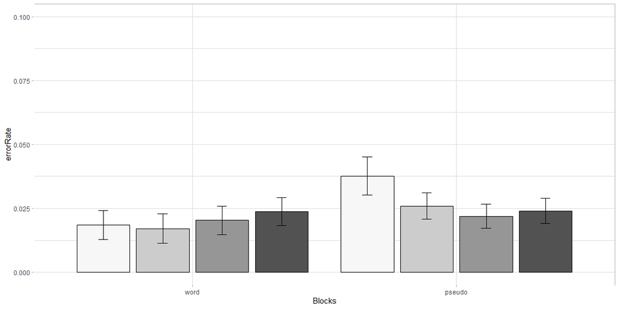

```r
# plot error rate by block and lexicality
# words
# reorder levels
accByBlock$block <- factor(accByBlock$block, c("b1", "b2", "b3", "b4"))
accByBlock$lexicality <- factor(accByBlock$lexicality, c("word", "pseudo"))
ggplot(accByBlock, aes(x = lexicality, y = errorRate, group = block, fill = block)) +
  geom_bar(stat = "identity", width=0.8, color= "black", position = position_dodge(0.9)) +
  scale_fill_brewer(palette="Greys") +
  scale_x_discrete("Blocks") +
  coord_cartesian(ylim = c(0,0.1)) +
  theme_light() +
  theme(legend.title = element_blank(),
        legend.position='none',
        axis.line.x = element_line(color="white"),
        axis.line.y = element_line(color="white"))+

   geom_errorbar(aes(ymin = errorRate - ci, ymax = errorRate + ci), width = .15,  #size=.5,
                position=position_dodge(.9))
```

These results reflected that responses to words in general had lower error rate than responses to pseudowords. But the response accuracy to pseudowords improved a great deal over the course of repetition.

The following table and plot shows the rt difference caused by blocks and lexicality. Likewise, error bars showing the confidence interval adjusted to remove between-subject variance.

| lexicality | block | N | meanRT | sdRT | seRT | ci_original | ci |
| --- | --- | --- | --- | --- | --- | --- | --- |
| pseudo | b1 | 78 | 1145.8639 | 77.28087 | 8.750335 | 17.15034 | 18.33449 |
| pseudo | b2 | 78 | 1058.4869 | 66.77650 | 7.560950 | 14.81919 | 15.84238 |
| pseudo | b3 | 78 | 1007.8445 | 54.20507 | 6.137516 | 12.02931 | 12.85987 |
| pseudo | b4 | 78 | 987.9679 | 70.04831 | 7.931409 | 15.54528 | 16.61860 |
| word | b1 | 78 | 989.1681 | 55.23427 | 6.254050 | 12.25771 | 13.10405 |
| word | b2 | 78 | 942.0375 | 51.59141 | 5.841577 | 11.44928 | 12.23980 |
| word | b3 | 78 | 919.9549 | 53.16804 | 6.020095 | 11.79917 | 12.61384 |
| word | b4 | 78 | 910.3991 | 55.54141 | 6.288826 | 12.32587 | 13.17691 |

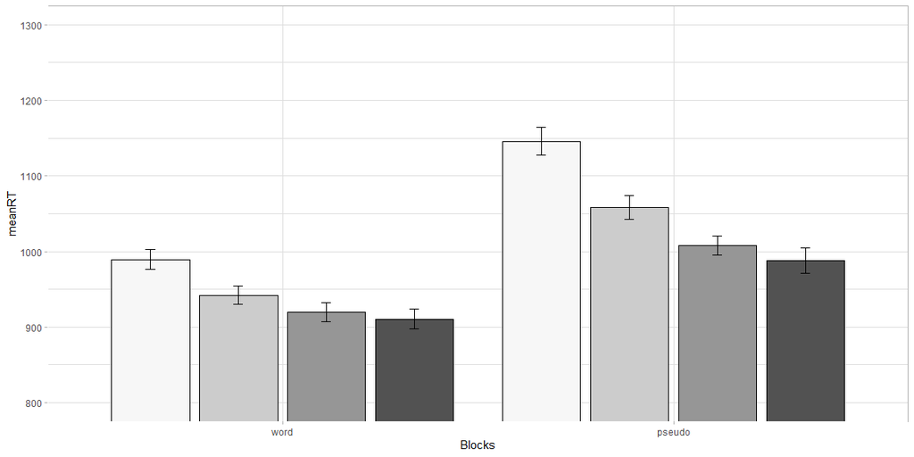

Response times to pseudowords were longer than those to words. However, unlike the error rate results, reponses times to both words and pseudowords seemed to have gradually become shorter due to repetitions over the 4 blocks.

## Part 2. Target phase

In the target phase, participants heard items that share the same initial segments with words and pseudowords presented in the prime phase, such as *hijack*, shaing /haɪdʒ/ with *hygiene*. We would like to investigate whether this kind of word-primed target words evoke slower response as compared to unprimed words and examine the magnitude of the delay.

### Data cleaning

Like in the prime phase, I also subset data for the test phase and removed participants with too many missing/incorrect responses.

```r
#subset LDT data only
testData <- df %>% filter(stimulus == "" & item != "")
#number of non-response
testData <- testData %>% mutate(missing = case_when(
   key_press == -1 ~ 1,
   TRUE ~ 0
  ))
table(testData$missing)
```

```
    0     1
18637   111
```

```r
BySubjMissing <- testData %>% group_by(subject) %>%
  summarise(missingAnswer = sum(missing))
View(BySubjMissing)
# score responses
testData <- testData %>% mutate(correct = case_when(
  lexicality == "pseudo" & key_press == 81 ~ 1,
  lexicality == "word" & key_press == 80 ~ 1,
  TRUE ~ 0
))
table(testData$correct)
```

```
    0     1
 1847 16901
```

```r
# performance by subject - summary
bySub0 <- testData %>% group_by(subject) %>%
  summarise(
                missingAnswer = sum(missing),
                invalidResponse = sum(rt<450),
                meanRT = mean(rt, na.rm = TRUE),
                sdRT = sd(rt, na.rm = TRUE),
                numResponse = length(correct),
                numCorrect = sum(correct),
                errorRate = 1 - mean(correct)
)
View(bySub0)
testValid <- testData %>%
  filter(!subject %in% c(233, 217, 331, 703, 98, 329, 501, 970),
         rt >= 450)
# Exclude invalid responses (rt < 450ms)
testValid <- testValid %>% filter(rt >= 450)
#Exclude fillers
testValid <- testValid %>% filter(condition != "f")
```

We also need to exclude target items whose corresponding prime item evoked incorrect responses more than 50% of the time (i.e. twice) during the training phase, because these targets were unlikely to have been primed effectively in this case.

```r
# exclude corresponding target trial if the prime item is more than twice incorrect
testValidExcluded <- testValid %>%
  anti_join(subset(accByInitials, errorRate > 0.5),
            by = c('initials','subject'))
```

We now have a cleaned dataset for the test phase.

### Data transformation

Next, I checked the raw rt data and found that it was positively-skewed with a longer right tail. But since the length of the longer rts were within reasonable range (3 seconds), they were not removed.

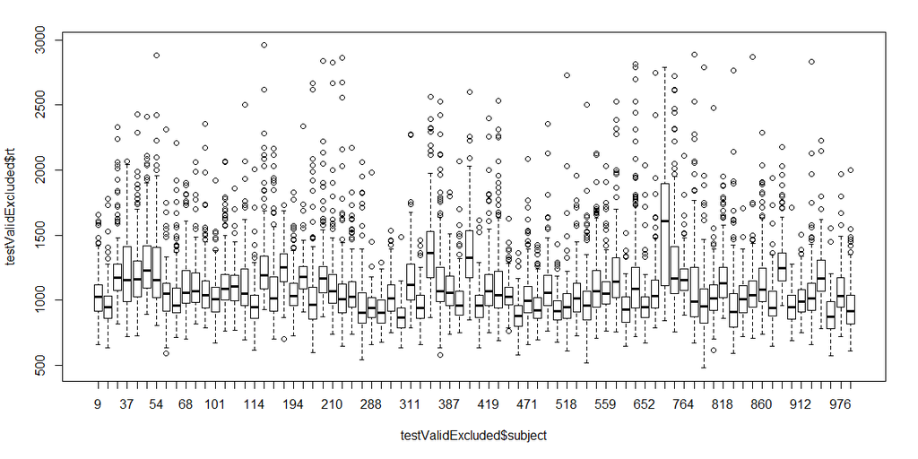

```r
#check RT
summary(testValidExcluded$rt)
png(paste(filePathOut, "QQplot_rawRTs_original.png", sep = ""), width = 1000, height = 1000)
qqmath(~rt | subject, data = testValidExcluded)
dev.off()
boxplot(testValidExcluded$rt ~ testValidExcluded$subject)
```

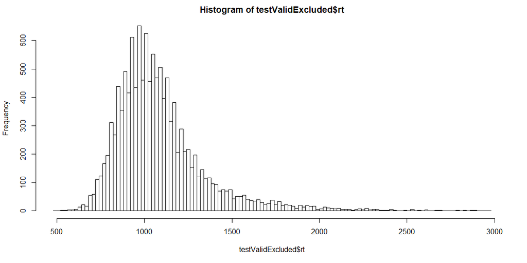

```r
hist(testValidExcluded$rt, breaks = 100)
```

In order to make the rt data more normally distributed, I did log transformation and inverse transformation on the raw data and plotted QQ plots, box plots and histograms to compare the distributions of the two transformations.

```r
# transform RTs
testValidExcluded$logRT <- log(testValidExcluded$rt)
testValidExcluded$invRT <- -1000/testValidExcluded$rt
```

```r
#check logRT
summary(testValidExcluded$logRT)
```

```
   Min. 1st Qu.  Median    Mean 3rd Qu.    Max.
  6.175   6.826   6.946   6.970   7.073   7.993
```

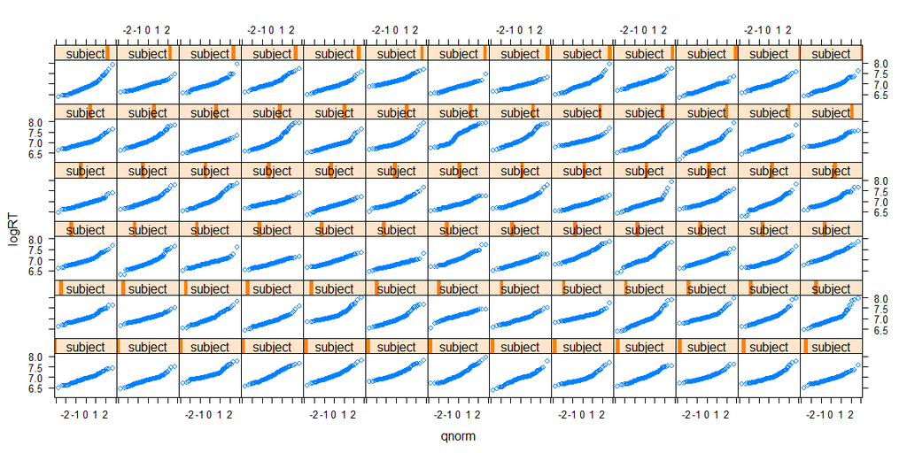

```r
qqmath(~logRT | subject, data = testValidExcluded)
```

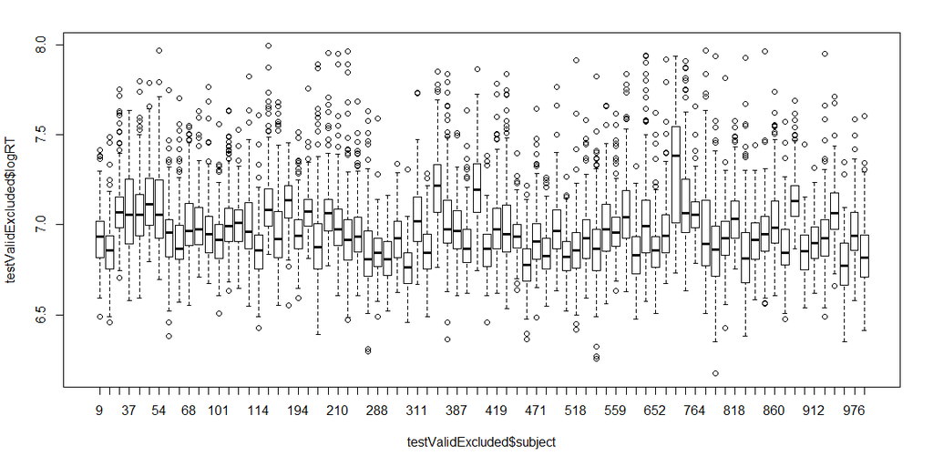

```r
boxplot(testValidExcluded$logRT ~ testValidExcluded$subject)
```

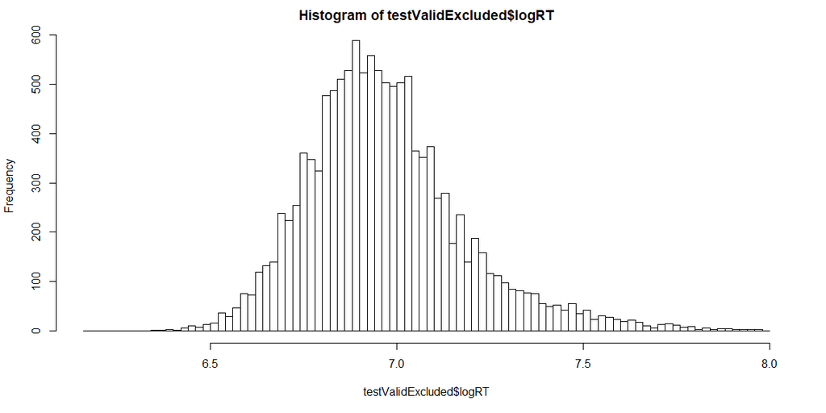

```r
hist(testValidExcluded$logRT, breaks = 100)
```

```r
#check invRT
summary(testValidExcluded$invRT)
```

```
   Min. 1st Qu.  Median    Mean 3rd Qu.    Max.
-2.0812 -1.0854 -0.9628 -0.9612 -0.8475 -0.3377
```

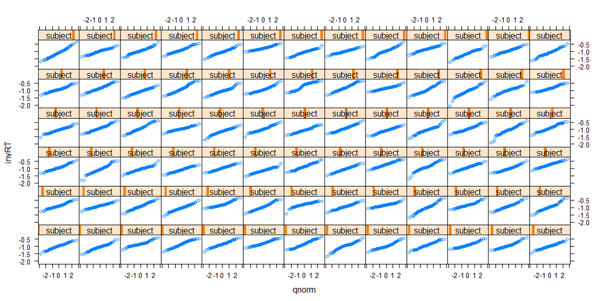

```r
qqmath(~invRT | subject, data = testValidExcluded)
```

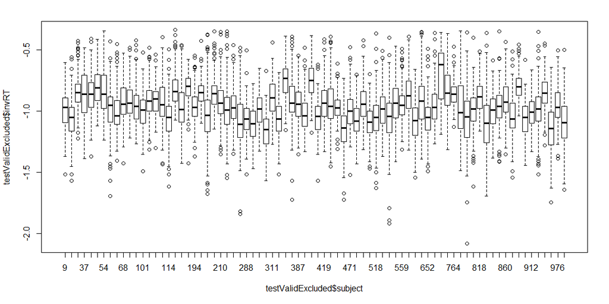

```r
boxplot(testValidExcluded$invRT ~ testValidExcluded$subject)
```

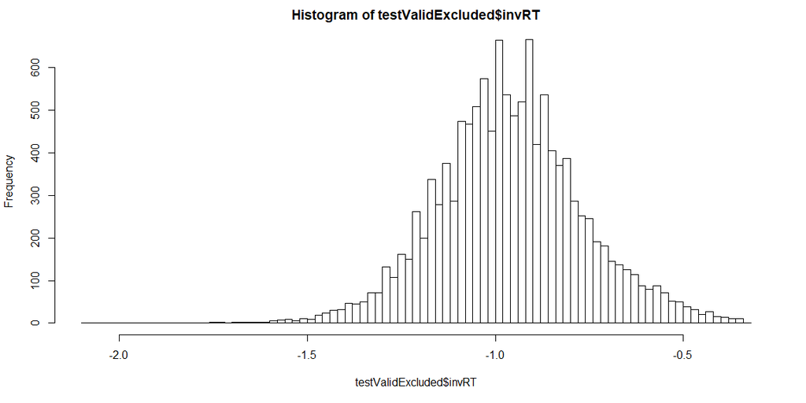

```r
hist(testValidExcluded$invRT, breaks = 100)
```

These plots suggest that inverse transformation normalised the data to a greater degree than log transformation. Therefore, we will conduct our statistical analyses using inversed rts.

### Accuracy visualisation

In order to examine specific differences between conditions within words and pseudowords, we grouped the conditions of interest based on the lexicality of the items.

```r
# create target word factor:
testValidExcluded <- testValidExcluded %>% mutate(targetWordFactor = as.factor(case_when(
  condition == "W"  ~ "W",
  condition == "WW"  ~ "WW",
  condition == "PW"  ~ "PW"
)))
# create target nonword factor for the conditions:
testValidExcluded <- testValidExcluded %>% mutate(targetNonwordFactor = as.factor(case_when(
  condition == "P"  ~ "P",
  condition == "PP"  ~ "PP",
  condition == "WP"  ~ "WP"
)))
```

We can now plot the error rate for word conditions, error bars indicate confidence intervals adjusted by removing between-subject variance:

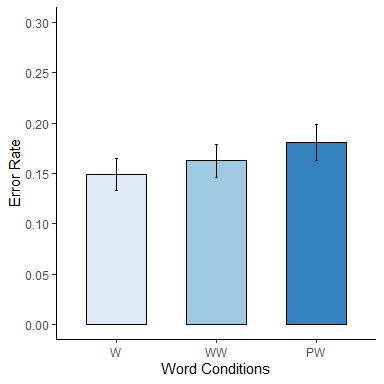

And the error rate for pseudoword conditions:

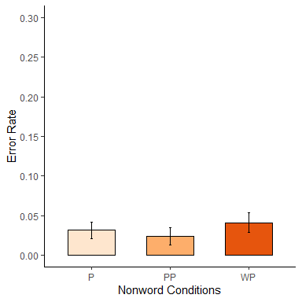

### Generalised linear mixed-effect models for accuracy

In order to find out whether there are significant error rate differences between conditions, I set relevant variables as factors first:

```r
## set factors for LME analyses
testValidExcluded$subject <- as.factor(testValidExcluded$subject)
testValidExcluded$correct <- as.factor(testValidExcluded$correct)
testValidExcluded$item <- as.factor(testValidExcluded$item)
testValidExcluded$lexicality <- as.factor(testValidExcluded$lexicality)
```

Then, I did generalised linear mixed-effect analysis with accuracy (dependent variable) and prime type for words (independent variable) as fixed effects, subject and item as random effects:

```r
### word
#dummy coding
#word factor
testValidExcluded$targetWordFactor <- factor(testValidExcluded$targetWordFactor, c("W", "WW", "PW"))
contrasts(testValidExcluded$targetWordFactor)
```

```
   WW PW
W   0  0
WW  1  0
PW  0  1
```

```r
#logistic mixed effect model for accuracy
accModelWord <- glmer(correct ~ 1 + targetWordFactor +
                        (1 + targetWordFactor|subject) +
                        (1 + targetWordFactor|item),
                      data = testValidExcluded,
                      family = binomial(link = "logit"),
                      control = glmerControl(optimizer="bobyqa",
                                             optCtrl = list(maxfun=2e5)))
summary(accModelWord)
```

```
Generalized linear mixed model fit by maximum likelihood (Laplace Approximation) ['glmerMod']
 Family: binomial  ( logit )
Formula: correct ~ 1 + targetWordFactor + (1 + targetWordFactor | subject) +
    (1 + targetWordFactor | item)
   Data: testValidExcluded
Control: glmerControl(optimizer = "bobyqa", optCtrl = list(maxfun = 2e+05))

     AIC      BIC   logLik deviance df.resid
  4072.3   4173.4  -2021.1   4042.3     6225

Scaled residuals:
     Min       1Q   Median       3Q      Max
-10.3450   0.0940   0.1792   0.3267   2.2584

Random effects:
 Groups  Name               Variance Std.Dev. Corr
 item    (Intercept)        3.792277 1.94738
         targetWordFactorWW 0.812696 0.90150   0.04
         targetWordFactorPW 0.172309 0.41510  -0.57  0.56
 subject (Intercept)        0.599144 0.77404
         targetWordFactorWW 0.239081 0.48896  -0.40
         targetWordFactorPW 0.009835 0.09917  -0.77  0.89
Number of obs: 6240, groups:  item, 162; subject, 78

Fixed effects:
                   Estimate Std. Error z value Pr(>|z|)
(Intercept)         2.89997    0.21648  13.396  < 2e-16 ***
targetWordFactorWW  0.01296    0.19869   0.065 0.947981
targetWordFactorPW -0.55254    0.15823  -3.492 0.000479 ***
---
Signif. codes:  0 ‘***’ 0.001 ‘**’ 0.01 ‘*’ 0.05 ‘.’ 0.1 ‘ ’ 1

Correlation of Fixed Effects:
            (Intr) trWFWW
trgtWrdFcWW -0.381
trgtWrdFcPW -0.544  0.535
convergence code: 0
boundary (singular) fit: see ?isSingular
```

```r
pairs(emmeans(accModelWord, ~targetWordFactor))
```

```
 contrast estimate    SE  df z.ratio p.value
 W - WW     -0.013 0.199 Inf -0.065  0.9977
 W - PW      0.553 0.158 Inf  3.492  0.0014
 WW - PW     0.566 0.176 Inf  3.218  0.0037

Results are given on the log odds ratio (not the response) scale.
P value adjustment: tukey method for comparing a family of 3 estimates
```

```r
### save model
saveRDS(accModelWord,"Exp4b_accModelWord.rds")
accModelWord <- readRDS("Exp4b_accModelWord.rds")
```

These results indicated that pseudoword-primed words evoked significantly more errors than unrpimed words and word-primed words.

The main effect of prime type for words was tested through the likelihood ratio test, by comparing nested models using chi-square:

```r
#compare to null model
accModelNullWord <- glmer(correct ~ 1 +
                            (1 + targetWordFactor|subject) +
                            (1 + targetWordFactor|item),
                          data = testValidExcluded,
                          family = binomial(link = "logit"),
                          control = glmerControl(optimizer="bobyqa",
                                                 optCtrl = list(maxfun=2e5)))
anova(accModelNullWord,accModelWord)
```

```
Data: testValidExcluded
Models:
accModelNullWord: correct ~ 1 + (1 + targetWordFactor | subject) + (1 + targetWordFactor |
accModelNullWord:     item)
accModelWord: correct ~ 1 + targetWordFactor + (1 + targetWordFactor | subject) +
accModelWord:     (1 + targetWordFactor | item)
                 npar    AIC    BIC  logLik deviance  Chisq Df Pr(>Chisq)
accModelNullWord   13 4081.5 4169.1 -2027.7   4055.5
accModelWord       15 4072.3 4173.4 -2021.1   4042.3 13.181  2   0.001373 **
---
Signif. codes:  0 ‘***’ 0.001 ‘**’ 0.01 ‘*’ 0.05 ‘.’ 0.1 ‘ ’ 1
```

I also did the analysis with prime type for pseudowords as the independent variable:

```r
### Pseudoword
#dummy coding
testValidExcluded$targetNonwordFactor <- factor(testValidExcluded$targetNonwordFactor, c("P", "PP", "WP"))
#logistic mixed effect model for accuracy
accModelNonword <- glmer(correct ~ 1 + targetNonwordFactor +
                           (1 + targetNonwordFactor |subject) +
                           (1 + targetNonwordFactor |item),
                         data = testValidExcluded,
                         family = binomial(link = "logit"),
                         control = glmerControl(optimizer="bobyqa",
                                                optCtrl = list(maxfun=2e5)))
summary(accModelNonword)
```

```
Generalized linear mixed model fit by maximum likelihood (Laplace Approximation) ['glmerMod']
 Family: binomial  ( logit )
Formula: correct ~ 1 + targetNonwordFactor + (1 + targetNonwordFactor |
    subject) + (1 + targetNonwordFactor | item)
   Data: testValidExcluded
Control: glmerControl(optimizer = "bobyqa", optCtrl = list(maxfun = 2e+05))

     AIC      BIC   logLik deviance df.resid
  1521.6   1622.7   -745.8   1491.6     6232

Scaled residuals:
    Min      1Q  Median      3Q     Max
-7.4171  0.0713  0.0963  0.1490  2.4298

Random effects:
 Groups  Name                  Variance Std.Dev. Corr
 item    (Intercept)           3.6596   1.9130
         targetNonwordFactorPP 3.0899   1.7578   -0.73
         targetNonwordFactorWP 1.0244   1.0121   -0.59  0.52
 subject (Intercept)           0.6385   0.7991
         targetNonwordFactorPP 0.0878   0.2963   -0.07
         targetNonwordFactorWP 0.2703   0.5199   -0.97 -0.19
Number of obs: 6247, groups:  item, 162; subject, 78

Fixed effects:
                      Estimate Std. Error z value Pr(>|z|)
(Intercept)             5.1933     0.4409  11.779   <2e-16 ***
targetNonwordFactorPP  -0.2830     0.6106  -0.464   0.6430
targetNonwordFactorWP  -0.9523     0.4868  -1.956   0.0504 .
---
Signif. codes:  0 ‘***’ 0.001 ‘**’ 0.01 ‘*’ 0.05 ‘.’ 0.1 ‘ ’ 1

Correlation of Fixed Effects:
            (Intr) trNFPP
trgtNnwrFPP -0.690
trgtNnwrFWP -0.805  0.585
convergence code: 0
boundary (singular) fit: see ?isSingular
```

```r
pairs(emmeans(accModelNonword, ~targetNonwordFactor))
```

```
 contrast estimate    SE  df z.ratio p.value
 P - PP      0.283 0.611 Inf 0.464   0.8883
 P - WP      0.952 0.487 Inf 1.956   0.1232
 PP - WP     0.669 0.512 Inf 1.307   0.3910

Results are given on the log odds ratio (not the response) scale.
P value adjustment: tukey method for comparing a family of 3 estimates
```

```r
### save model
saveRDS(accModelNonword,"Exp4b_accModelNonword.rds")
accModelNonword <- readRDS("Exp4b_accModelNonword.rds")
```

```r
#compare to null model
accModelNullNonword <- glmer(correct ~ 1+
                               (1 + targetNonwordFactor|subject) +
                               (1 + targetNonwordFactor|item),
                             data = testValidExcluded,
                             family = binomial(link = "logit"),
                             control = glmerControl(optimizer="bobyqa",
                                                    optCtrl = list(maxfun=2e5)))
anova(accModelNullNonword,accModelNonword)
```

```
Data: testValidExcluded
Models:
accModelNullNonword: correct ~ 1 + (1 + targetNonwordFactor | subject) + (1 + targetNonwordFactor |
accModelNullNonword:     item)
accModelNonword: correct ~ 1 + targetNonwordFactor + (1 + targetNonwordFactor |
accModelNonword:     subject) + (1 + targetNonwordFactor | item)
                    npar    AIC    BIC  logLik deviance  Chisq Df Pr(>Chisq)
accModelNullNonword   13 1522.0 1609.6 -747.98   1496.0
accModelNonword       15 1521.6 1622.7 -745.80   1491.6 4.3588  2     0.1131
```

### RTs visualisation

I also plotted the response times to different word conditions:

| targetWordFactor | N | meanRT | sdRT | seRT | ci_original | ci |
| --- | --- | --- | --- | --- | --- | --- |
| W | 78 | 1079.013 | 45.10831 | 5.107510 | 10.01054 | 10.96599 |
| WW | 78 | 1093.816 | 61.80981 | 6.998583 | 13.71697 | 15.02619 |
| PW | 78 | 1082.670 | 51.07332 | 5.782915 | 11.33430 | 12.41611 |

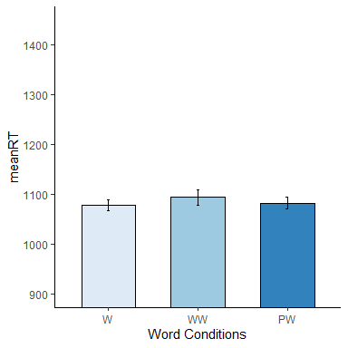

And pseudoword conditions:

| targetNonwordFactor | N | meanRT | sdRT | seRT | ci_original | ci |
| --- | --- | --- | --- | --- | --- | --- |
| P | 78 | 1099.692 | 60.50299 | 6.850614 | 13.42696 | 14.70849 |
| PP | 78 | 1080.352 | 47.46532 | 5.374389 | 10.53361 | 11.53899 |
| WP | 78 | 1112.818 | 47.88780 | 5.422225 | 10.62737 | 11.64170 |

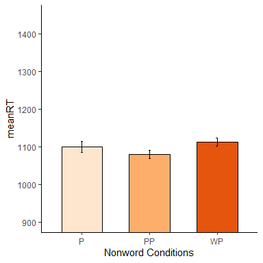

### Linear mixed-effect models for RTs

Here, I did linear mixed-effect analysis with inversed rts as the dependent variable and prime type for words as the independent variable. Since we are testing two planned contrasts here: word-primed word vs unprimed word (WW - W), word-primed word vs pseudoword-primed word (WW - PW), we don't need to carry out correction for multiple comparisons.

```r
#remove NAs from dataset
testWord <- testValidExcluded %>%
  select(-accuracy, -attempt_number, -order, -targetNonwordFactor) %>%
  drop_na(targetWordFactor)
#define contrasts for the word model:
#dummy coding
testWord$targetWordFactor <- factor(testWord$targetWordFactor, c("WW","W","PW"))
contrasts(testWord$targetWordFactor)
```

```
   W PW
WW 0  0
W  1  0
PW 0  1
```

```r
# inverse RT - this one looks more normal than the log transformation
invRTmodelWord <- lmer(invRT ~ 1 + targetWordFactor +
                         (1 + targetWordFactor|subject) +
                         (1 + targetWordFactor|item),
                       data = testWord,
                       REML=FALSE,
                       control = lmerControl(optimizer="bobyqa",
                                              optCtrl = list(maxfun=2e5))
                       )
summary(invRTmodelWord)
```

```
Linear mixed model fit by maximum likelihood . t-tests use Satterthwaite's method [
lmerModLmerTest]
Formula: invRT ~ 1 + targetWordFactor + (1 + targetWordFactor | subject) +
    (1 + targetWordFactor | item)
   Data: testWord
Control: lmerControl(optimizer = "bobyqa", optCtrl = list(maxfun = 2e+05))

     AIC      BIC   logLik deviance df.resid
 -4691.6  -4583.8   2361.8  -4723.6     6224

Scaled residuals:
    Min      1Q  Median      3Q     Max
-6.4558 -0.6011 -0.0388  0.5459  4.5858

Random effects:
 Groups   Name               Variance  Std.Dev. Corr
 item     (Intercept)        0.0070351 0.08388
          targetWordFactorW  0.0015782 0.03973  -0.25
          targetWordFactorPW 0.0008004 0.02829  -0.43  0.68
 subject  (Intercept)        0.0101368 0.10068
          targetWordFactorW  0.0006159 0.02482  0.03
          targetWordFactorPW 0.0007249 0.02692  0.16  0.98
 Residual                    0.0242814 0.15582
Number of obs: 6240, groups:  item, 162; subject, 78

Fixed effects:
                     Estimate Std. Error         df t value Pr(>|t|)
(Intercept)         -0.961808   0.013610 122.484207 -70.669   <2e-16 ***
targetWordFactorW   -0.013499   0.006402  85.734943  -2.109   0.0379 *
targetWordFactorPW  -0.013084   0.006148  73.375419  -2.128   0.0367 *
---
Signif. codes:  0 ‘***’ 0.001 ‘**’ 0.01 ‘*’ 0.05 ‘.’ 0.1 ‘ ’ 1

Correlation of Fixed Effects:
            (Intr) trgWFW
trgtWrdFctW -0.182
trgtWrdFcPW -0.152  0.632
```

We also need to check the model residual's normality and homoscedasticity:

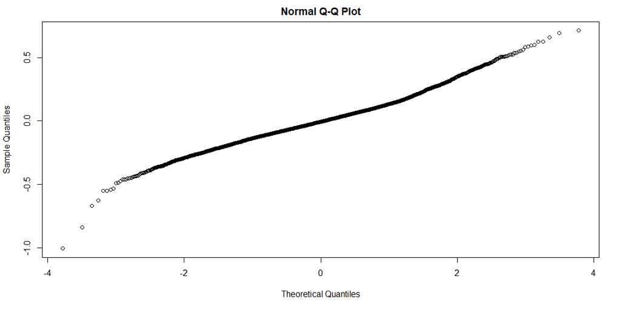

```r
qqnorm(resid(invRTmodelWord))
```

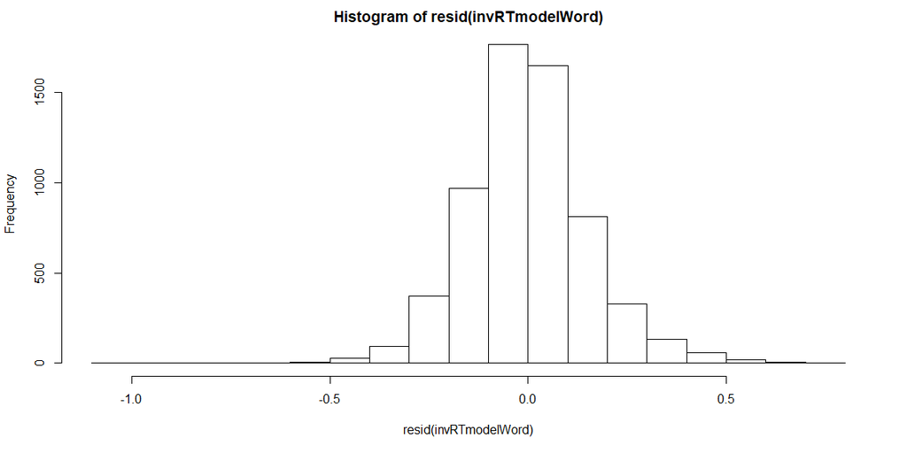

```r
hist(resid(invRTmodelWord))
```

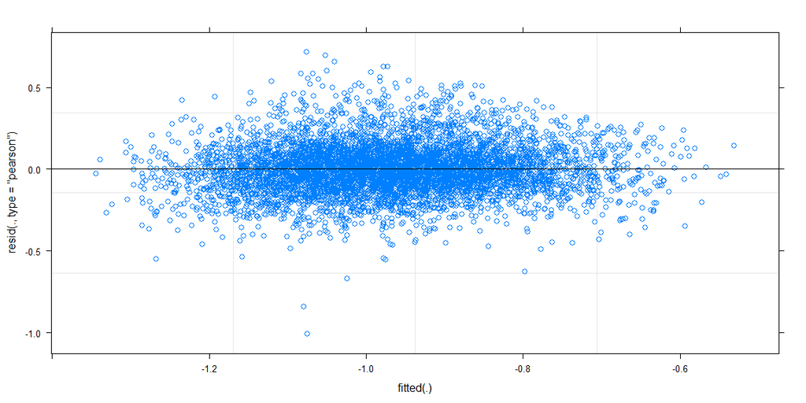

```r
plot(invRTmodelWord)
```

It seems that these assumptions were met.

As predicted, the model results showed that word priming evoked the competitor priming effect such that word-primed words were recognised significantly more slowly than unprimed words and pseudoword-primed words. However, it should be noted that the effect size (as represented by the estimate) was also smaller than that shown in our previous experiment in which the prime-target lag was shorter.

I then did the likelihood ratio test on nested models to check the main effect of prime type for words:

```r
#null model
invRTmodelWordNull <- lmer(invRT ~ 1 +
                             (1+targetWordFactor|subject) +
                             (1+targetWordFactor|item),
                           data = testWord,
                           REML=FALSE,
                           control = lmerControl(optimizer="bobyqa",
                                                 optCtrl = list(maxfun=2e5)))
anova(invRTmodelWordNull, invRTmodelWord)
```

```
Data: testWord
Models:
invRTmodelWordNull: invRT ~ 1 + (1 + targetWordFactor | subject) + (1 + targetWordFactor |
invRTmodelWordNull:     item)
invRTmodelWord: invRT ~ 1 + targetWordFactor + (1 + targetWordFactor | subject) +
invRTmodelWord:     (1 + targetWordFactor | item)
                   npar     AIC     BIC logLik deviance  Chisq Df Pr(>Chisq)
invRTmodelWordNull   14 -4690.3 -4596.0 2359.2  -4718.3
invRTmodelWord       16 -4691.6 -4583.8 2361.8  -4723.6 5.3343  2    0.06945 .
---
Signif. codes:  0 ‘***’ 0.001 ‘**’ 0.01 ‘*’ 0.05 ‘.’ 0.1 ‘ ’ 1
```

The main effect of prime type for words is marginal.

Similarly, I also did the lme analysis with prime type for pseudowords as the independent variable:

```r
summary(invRTmodelNonword)
```

```
Linear mixed model fit by maximum likelihood . t-tests use Satterthwaite's method [
lmerModLmerTest]
Formula: invRT ~ 1 + targetNonwordFactor + (1 + targetNonwordFactor |
    subject) + (1 + targetNonwordFactor | item)
   Data: testValidExcluded
Control: lmerControl(optimizer = "bobyqa", optCtrl = list(maxfun = 2e+05))

     AIC      BIC   logLik deviance df.resid
 -6063.3  -5955.5   3047.7  -6095.3     6231

Scaled residuals:
    Min      1Q  Median      3Q     Max
-5.2453 -0.5740 -0.0893  0.4944  4.8085

Random effects:
 Groups   Name                  Variance  Std.Dev. Corr
 item     (Intercept)           4.056e-03 0.063688
          targetNonwordFactorP  1.003e-03 0.031671 -0.25
          targetNonwordFactorWP 2.059e-03 0.045374 -0.30  0.61
 subject  (Intercept)           1.039e-02 0.101936
          targetNonwordFactorP  1.474e-07 0.000384  1.00
          targetNonwordFactorWP 5.741e-04 0.023961 -0.40 -0.40
 Residual                       1.948e-02 0.139567
Number of obs: 6247, groups:  item, 162; subject, 78

Fixed effects:
                        Estimate Std. Error         df t value Pr(>|t|)
(Intercept)            -0.968541   0.012951 104.413905 -74.787  < 2e-16 ***
targetNonwordFactorP    0.019813   0.004989 157.509592   3.972 0.000108 ***
targetNonwordFactorWP   0.032413   0.006241  99.107236   5.194  1.1e-06 ***
---
Signif. codes:  0 ‘***’ 0.001 ‘**’ 0.01 ‘*’ 0.05 ‘.’ 0.1 ‘ ’ 1

Correlation of Fixed Effects:
            (Intr) trgNFP
trgtNnwrdFP -0.186
trgtNnwrFWP -0.338  0.474
convergence code: 0
boundary (singular) fit: see ?isSingular
```

The results indicated siginificantly faster response for pseudoword-primed pseudoword compared to unprimed and word-primed conditions.

Checking the normality and homoscedasticity of the model residual:

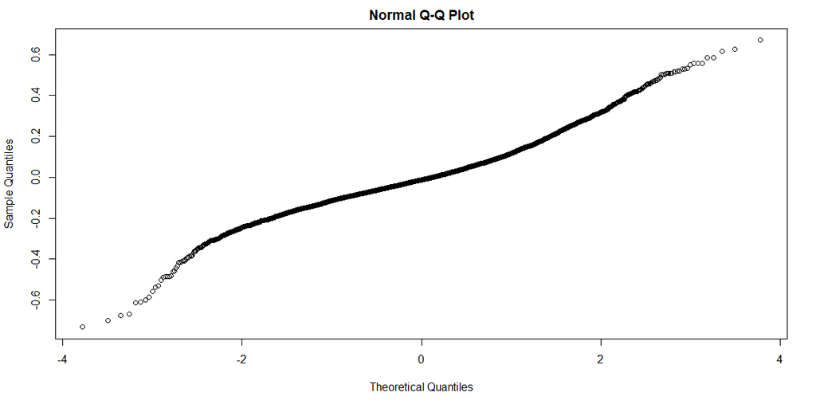

```r
qqnorm(resid(invRTmodelNonword))
```

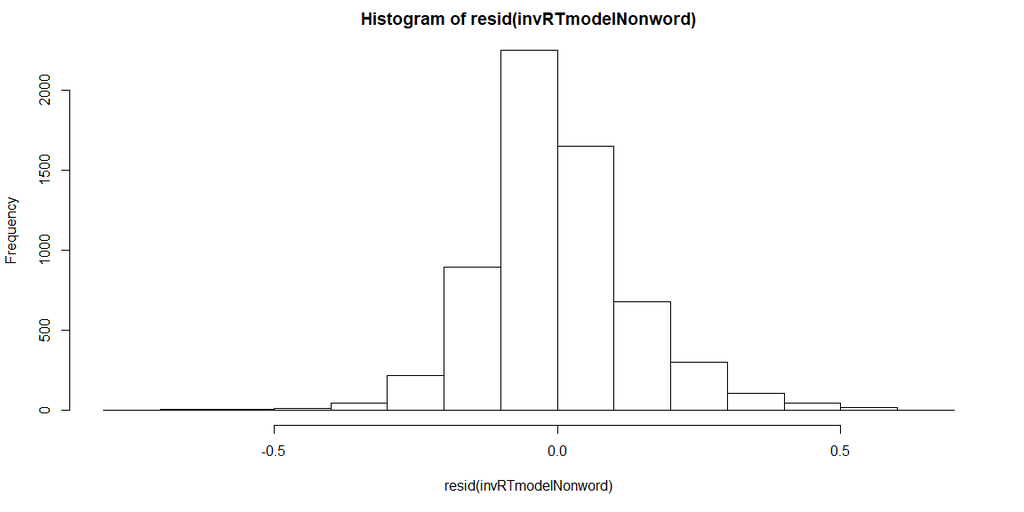

```r
hist(resid(invRTmodelNonword))
```

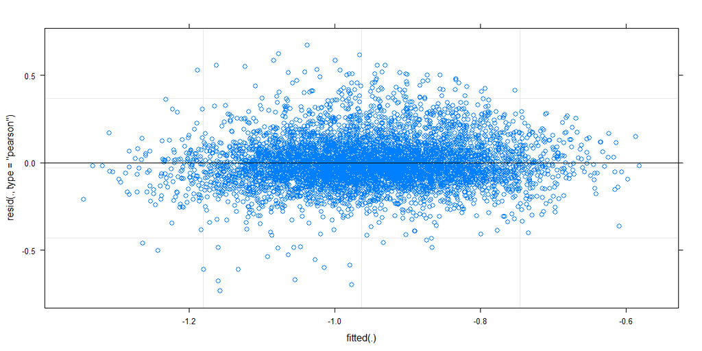

```r
plot(invRTmodelNonword)
```

```r
#null model
invRTmodelNonwordNull <- lmer(invRT ~ 1 +
                                (1 + targetNonwordFactor|subject) +
                                (1 + targetNonwordFactor |item),
                              data = testValidExcluded,
                              REML=FALSE,
                              control = lmerControl(optimizer="bobyqa",
                                                    optCtrl = list(maxfun=2e5)))
#likelyhood ratio test
anova(invRTmodelNonwordNull, invRTmodelNonword)
```

```
Data: testValidExcluded
Models:
invRTmodelNonwordNull: invRT ~ 1 + (1 + targetNonwordFactor | subject) + (1 + targetNonwordFactor |
invRTmodelNonwordNull:     item)
invRTmodelNonword: invRT ~ 1 + targetNonwordFactor + (1 + targetNonwordFactor |
invRTmodelNonword:     subject) + (1 + targetNonwordFactor | item)
                      npar     AIC     BIC logLik deviance  Chisq Df Pr(>Chisq)
invRTmodelNonwordNull   14 -6041.5 -5947.1 3034.7  -6069.5
invRTmodelNonword       16 -6063.3 -5955.5 3047.7  -6095.3 25.865  2  2.419e-06 ***
---
Signif. codes:  0 ‘***’ 0.001 ‘**’ 0.01 ‘*’ 0.05 ‘.’ 0.1 ‘ ’ 1
```

The main effect of prime type for pseudowords is significant.

### Power Analysis for future experiments

Since the effect size of the competitor priming effect under current experimental design is smaller than what we expected, we decided to conduct a new power analysis to decide how many participants we should recruit for future experiments if we were to use a similar experimental design.

Here, I set the effect size to a smaller value than what we have seen in the current experiment.

```r
#set the effect size of interest
fixef(invRTmodelWord2)["targetWordFactorWW"] <- 0.01
#Add more subjects
invRTmodelWord3 <- extend(invRTmodelWord2, along = "subject", n = 350)
# calculate power
#powerSim(invRTmodelWord3, test=fixed("targetWordFactor"))
```

```r
#calculate the sample size needed for 80% power
power_curve <- powerCurve(invRTmodelWord3, test=fixed("targetWordFactor"), along = "subject", breaks=seq(70,350,10))
saveRDS(power_curve, 'power_curve.rds')
```

```r
readRDS('power_curve.rds')
```

```
Power for predictor 'targetWordFactor', (95% confidence interval),
by largest value of subject:
     70: 31.90% (29.02, 34.89) - 3745 rows
     80: 34.50% (31.55, 37.54) - 4283 rows
     90: 36.90% (33.90, 39.98) - 4819 rows
    100: 39.60% (36.55, 42.71) - 5356 rows
    110: 40.50% (37.44, 43.62) - 5894 rows
    120: 43.20% (40.10, 46.34) - 6428 rows
    130: 46.00% (42.88, 49.15) - 6959 rows
    140: 47.20% (44.07, 50.35) - 7491 rows
    150: 48.70% (45.56, 51.85) - 8027 rows
    160: 51.30% (48.15, 54.44) - 8564 rows
    170: 51.40% (48.25, 54.54) - 9102 rows
    180: 53.60% (50.45, 56.73) - 9638 rows
    190: 54.30% (51.15, 57.42) - 10173 rows
```

[output cut: 18 more lines]

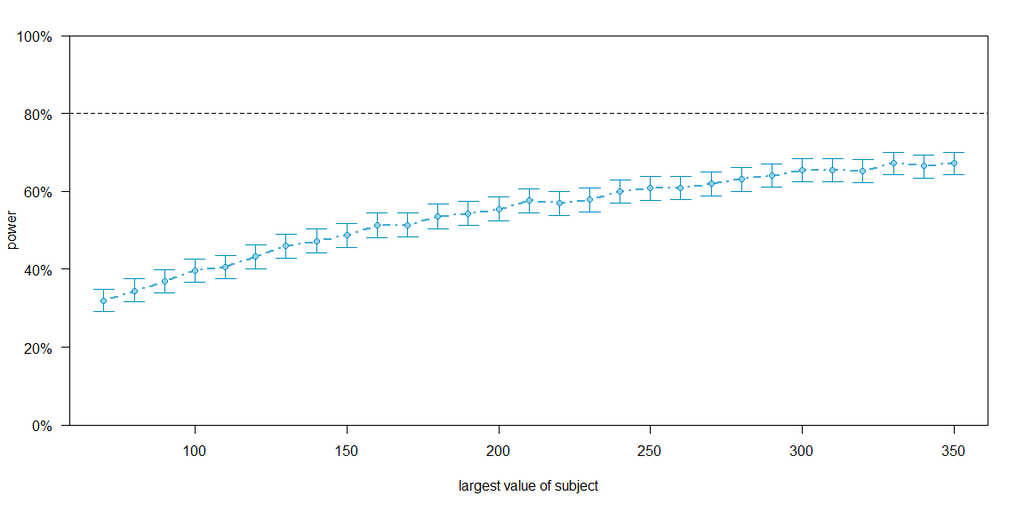

```r
#print(power_curve)
plot(power_curve)
```

The power curve results suggest that the power will reach a plateau before passing the 80% threshold despite the increasing number of subjects. This is not ideal, so I reset the desired effect size to 0.013, which is similar to that in this experiment.

```r
#set a different effect size of interest
fixef(invRTmodelWord2)["targetWordFactorWW"] <- 0.013
#Add more subjects
invRTmodelWord4 <- extend(invRTmodelWord2, along = "subject", n = 350)
```

```r
#calculate the sample size needed for 80% power
power_curve2 <- powerCurve(invRTmodelWord4, test=fixed("targetWordFactor"), along = "subject", breaks=seq(70,350,10))
saveRDS(power_curve2, 'power_curve2.rds')
```

```r
readRDS('power_curve2.rds')
```

```
Power for predictor 'targetWordFactor', (95% confidence interval),
by number of levels in subject:
     70: 47.70% (44.56, 50.85) - 3745 rows
     80: 50.20% (47.05, 53.34) - 4283 rows
     90: 53.10% (49.95, 56.23) - 4819 rows
    100: 58.10% (54.97, 61.18) - 5356 rows
    110: 60.20% (57.09, 63.25) - 5894 rows
    120: 62.60% (59.52, 65.61) - 6428 rows
    130: 65.40% (62.36, 68.35) - 6959 rows
    140: 66.60% (63.58, 69.52) - 7491 rows
    150: 69.30% (66.34, 72.15) - 8027 rows
    160: 71.30% (68.39, 74.09) - 8564 rows
    170: 72.10% (69.21, 74.86) - 9102 rows
    180: 73.40% (70.55, 76.12) - 9638 rows
    190: 74.10% (71.27, 76.79) - 10173 rows
```

[output cut: 18 more lines]

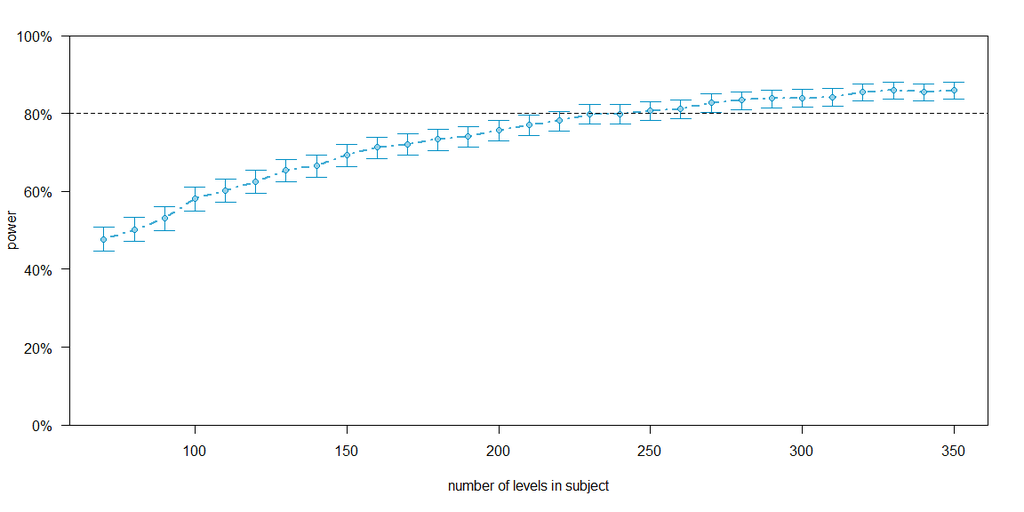

```r
#print(power_curve)
plot(power_curve2)
```

This power curve indicates that we will need to recruit around 250 participants for future experiments in order to reach 80% power.